# Theta re-estimation using ASTRAL

```r
knitr::opts_chunk$set(echo = TRUE, warning = FALSE, message = FALSE)

library(tidyverse)
library(cowplot)
library(ggrepel)
library(ggtree)
library(viridis)
library(kableExtra)
source("C:/bin/core/r/design.r")
source("C:/bin/core/r/get_tree_info.r")
library(here)
#this.dir <- dirname(parent.frame(2)$ofile)
#setwd(this.dir)
```

```r
# Table of loci counts if --theta filters are not disabled
#| Simulation | Total loci | Loci used for coalescent tree |
#| ---------- | ---------- | ----------------------------- |
#| A | 200 | 85 |
#| B | 200 | 45 |
#| C | 200 | 139 |
```

2. For each branch in the species tree, I took the branch length from the input tree ($l_1$) and the coalescent tree ($l_2$) and re-calculated $\theta$ using the method described in the paper (page 14, line 17):

$$\hat{\theta} = 2 \frac{l_1}{l_2}$$

3. I recovered the theta values $\theta$ used as input for the simulations from the file `Yan-etal-2022/data/SimulatedData/neut_ver3_genetree2.named.mod`, as the number following the `#` symbol in the branch lengths in the provided tree:

```
ALPHABET: A C G T
ORDER: 0
SUBST_MOD: SSREV
BACKGROUND: 0.289849 0.210150 0.210150 0.289849
RATE_MAT:
  -0.890871    0.108469    0.631337    0.151064
   0.149606   -1.150516    0.130141    0.870769
   0.870769    0.130141   -1.150516    0.149606
   0.151064    0.631337    0.108469   -0.890871
TREE: (((halLeu:0.05373562#0,nipNip:0.05176648#0)taeGut-aptFor:0.04155687#0.04578784,galGal:0.1660553#0)taeGut-galGal:0.0406841#0.04578784,((((((aptHaa:0.00138725#0,aptOwe:0.0016341#0)aptHaa-aptOwe:0.00305054#0.006321079,aptRow:0.00410494#0)aptHaa-aptRow:0.0277496#0.019876606,(casCas:0.0115461#0,dro…
```

```r
a_data = read_tsv("caseA-comps.tsv")
a_data$text = a_data$label
b_data = read_tsv("caseB-comps.tsv")
b_data$text = NA
c_data = read_tsv("caseC-comps.tsv")
c_data$text = NA
# Read the files and add a text column in case we want to label them in subsets later

sim_data = rbind(a_data, b_data, c_data)
# Combine datasets
```

Please note that simulations in Figure 2 of the paper are offset by one letter to their labels here:

| Case | Figure 2 panel |
| --- | --- |
| A | B |
| B | C |
| C | D |

# 1 Comparing estimated thetas to input thetas

## 1.1 Regression

This results in the following, with the $\theta$ used to simulate the data on the x-axis and the $\hat{\theta}$ estimated from the data as outlind above on the y-axis. Each simulation case is represented by a different color. Lines represent the linear regression between the two sets of $\theta$s and the dashed grey line is a 1-to-1 line, which is where we would hope the points fall.

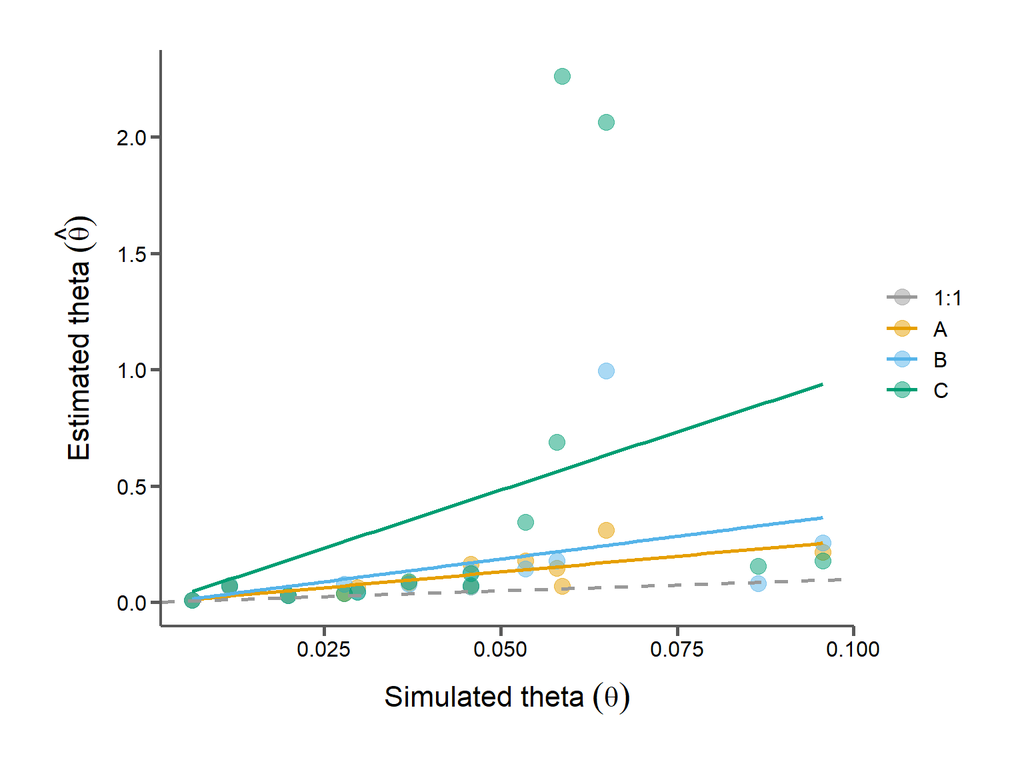

```r
#sim_data = sim_data %>% mutate(est.theta.2 = bl.subs/bl.coal)
sim_data = sim_data %>%
  mutate(est.theta = 2 * (bl.subs / bl.coal)) %>%
  mutate(est.theta = replace(est.theta, is.infinite(est.theta), NA)) %>%
  mutate(theta.diff = est.theta - sim.theta)

cols = corecol(pal="wilke", numcol=3)
names(cols) = c("A", "B", "C")
# Set up the colors

labels = sim_data %>% group_by(node) %>% summarize(theta=sim.theta)
labels = unique(labels)
# Another way to get some labels

reg_p = ggplot(sim_data, aes(x=sim.theta, y=est.theta, color=sim, label=text)) +
  geom_point(size=4, alpha=0.5) +
  geom_smooth(method="lm", se=F) +
  geom_abline(aes(slope=1, intercept=0, color="1:1"), size=1, linetype="dashed", show.legend=F) +
  #geom_text_repel(color="#333333", size=3) +
  #geom_text_repel(color="#333333", angle=90, nudge_y=0.2) +
  xlab(expression('Simulated theta' ~ ( theta ))) +
  ylab(expression('Estimated theta' ~ ( hat(theta) ))) +
  scale_color_manual(values=c("1:1"="#999999", cols)) +
  bartheme()
print(reg_p)
```

```r
# Plot the data and display
```

## 1.2 Differences

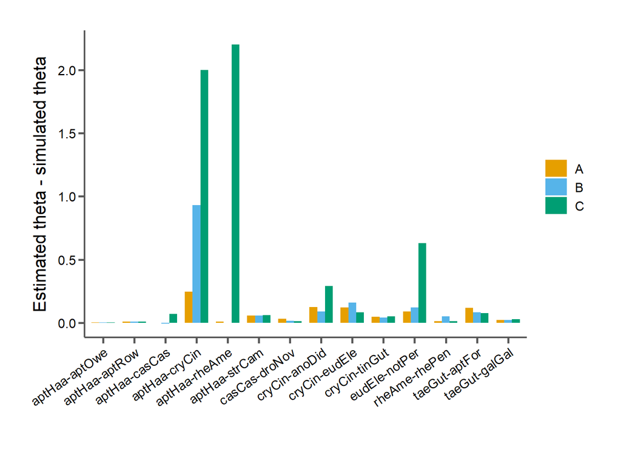

```r
min_diffs = sim_data %>% group_by(label) %>% summarize(min.theta.diff=min(theta.diff))
max_theta_diff = max(sim_data$theta.diff)

cols = corecol(pal="wilke", numcol=3)
names(cols) = c("A", "B", "C")
# Set up the colors

diff_p = ggplot(sim_data, aes(x=label, y=theta.diff, fill=sim)) +
  #geom_segment(data=min_diffs, aes(x=label, xend=label, y=0, yend=min.theta.diff), color="#666666", linetype="dotted") +
  #geom_point(size=2, alpha=0.5) +
  geom_bar(stat="identity", position="dodge", width=0.75) +
  #geom_smooth(method="lm", se=F) +
  #geom_abline(aes(slope=1, intercept=0, color="1:1"), size=1, linetype="dashed", show.legend=F) +
  #geom_text_repel(color="#333333", size=3) +
  #geom_text_repel(color="#333333", angle=90, nudge_y=0.2) +
  #ylim(c(-0.1,2)) +
  xlab("") +
  ylab("Estimated theta - simulated theta") +
  scale_fill_manual(values=c(cols)) +
  bartheme() +
  theme(axis.text.x = element_text(angle=35, hjust=1))
print(diff_p)
```

```r
# Plot the data and display

#theta_comps = plot_grid(reg_p, diff_p, ncol=2)
#print(theta_comps)
```

# 2 Case A

For reference, here are the trees with various branch lengths

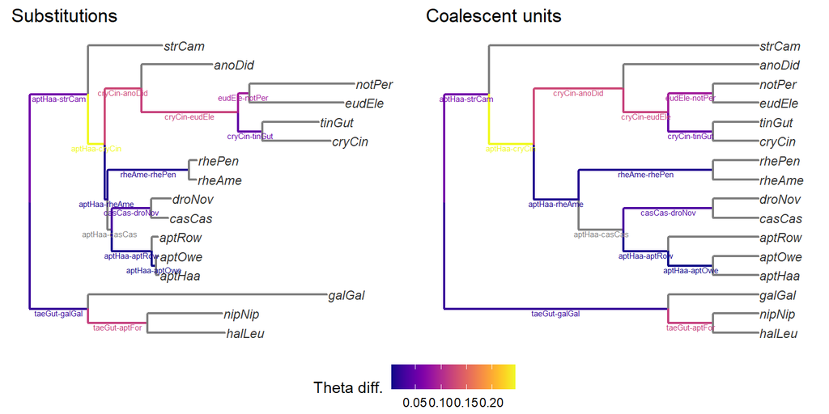

```r
sim_data_A = sim_data %>% filter(sim=="A") %>% select(-node)
# Get the data for the current case

sim_treefile = "sims.tre"
sim_tree = read.tree(file=sim_treefile)
tree_to_df_list = treeToDF(sim_tree)
sim_tree_info_orig = tree_to_df_list[["info"]]
# Read the tree and parse the info to properly add branch labels later

sim_tree_info = merge(sim_tree_info_orig, sim_data_A, by="label", all.x=T)
sim_tree_info = sim_tree_info %>% arrange(node)
# Merge the current theta info with the tree info to color branches by theta.diff

sim_t = ggtree(sim_tree, size=0.8, ladderize=F, aes(color=sim_tree_info$theta.diff)) +
  scale_color_viridis(name="Theta diff.", option="C") +
  xlim(0,0.25) +
  geom_tiplab(color="#333333", fontface='italic', size=3) +
  geom_text(aes(x=branch, label=ifelse(sim_tree_info$node.type=="internal", sim_tree_info$label, "")), nudge_y=-0.2, size=2) +
  #geom_text(aes(x=branch, label=ifelse(sim_tree_info$branch.length>0, signif(sim_tree_info$branch.length, 3), "")), nudge_y=0.35, size=2) +
  ggtitle("Substitutions") +
  theme(legend.position="bottom")
#print(sim_t)
# Plot and display the tree

####################

theta_treefile = "sims-theta.tre"
theta_tree = read.tree(file=theta_treefile)
tree_to_df_list = treeToDF(theta_tree)
theta_tree_info = tree_to_df_list[["info"]]
# Read the tree and parse the info to properly add branch labels later

theta_t = ggtree(theta_tree, size=0.8, ladderize=F) +
  xlim(0,0.35) +
  geom_tiplab(color="#333333", fontface='italic', size=2) +
  geom_text(aes(x=branch, label=ifelse(theta_tree_info$node.type=="internal", theta_tree_info$label, "")), nudge_y=-0.2, size=2) +
  #geom_text(aes(x=branch, label=ifelse(theta_tree_info$branch.length>0, signif(theta_tree_info$branch.length, 3), "")), nudge_y=0.35, size=2) +
  ggtitle("Simulated theta")
#print(theta_t)
# Plot and display the tree

####################

casefile = "caseA-coalescent.tre"
coal_tree = read.tree(file=casefile)
tree_to_df_list = treeToDF(coal_tree)
coal_tree_info = tree_to_df_list[["info"]]
# Read the tree and parse the info to properly add branch labels later

coal_tree_info$label = sim_tree_info$label
# Add the labels to the coal tree info (should be ok since everything is in the same order)

coal_tree_info = merge(coal_tree_info, sim_data_A, by="label", all.x=T)
coal_tree_info = coal_tree_info %>% arrange(node)
# Merge the current theta info with the coal tree info to color branches by theta.diff

coal_t = ggtree(coal_tree, size=0.8, ladderize=F, aes(color=coal_tree_info$theta.diff)) +
  scale_color_viridis(name="Theta diff.", option="C") +
  xlim(0,8) +
  geom_tiplab(color="#333333", fontface='italic', size=3) +
  geom_text(aes(x=branch, label=ifelse(coal_tree_info$node.type=="internal", sim_tree_info$label, "")), nudge_y=-0.2, size=2) +
  #geom_text(aes(x=branch, label=ifelse(coal_tree_info$branch.length>0, signif(coal_tree_info$branch.length, 3), "")), nudge_y=0.35, size=2) +
  ggtitle("Coalescent units")
#print(coal_t)
# Plot and display the tree

leg = get_legend(sim_t)

case_A_trees_main = plot_grid(sim_t + theme(legend.position="none"),
                         coal_t + theme(legend.position="none"),
                         ncol=2)
case_A_trees = plot_grid(case_A_trees_main, leg, nrow=2, rel_heights=c(1,0.15))

print(case_A_trees)
```

```r
sim_data %>%
  filter(sim=="A") %>%
  select(label, bl.subs, bl.coal, est.theta, sim.theta, theta.diff) %>%
  rename(Branch=label, Branch.length.subs=bl.subs, Branch.length.coalescent=bl.coal, Estimated.theta=est.theta, Simulated.theta=sim.theta, Theta.diff=theta.diff) %>%
  kable() %>%
  kable_styling(bootstrap_options=c("striped", "condended", "responsive"), full_width=F)
```

| Branch | Branch.length.subs | Branch.length.coalescent | Estimated.theta | Simulated.theta | Theta.diff |
| --- | --- | --- | --- | --- | --- |
| taeGut-aptFor | 0.0415569 | 0.5062437 | 0.1641773 | 0.0457878 | 0.1183895 |
| aptHaa-aptOwe | 0.0030505 | 0.6438651 | 0.0094757 | 0.0063211 | 0.0031546 |
| cryCin-tinGut | 0.0172068 | 0.4082675 | 0.0842918 | 0.0370186 | 0.0472732 |
| eudEle-notPer | 0.0079941 | 0.1089601 | 0.1467344 | 0.0579119 | 0.0888225 |
| aptHaa-aptRow | 0.0277496 | 1.9415101 | 0.0285856 | 0.0198766 | 0.0087090 |
| casCas-droNov | 0.0273773 | 0.8714064 | 0.0628347 | 0.0296944 | 0.0331403 |
| cryCin-eudEle | 0.0672093 | 0.6246519 | 0.2151896 | 0.0955806 | 0.1196090 |
| aptHaa-casCas | 0.0028599 | 0.0000000 | NA | 0.0864488 | NA |
| rheAme-rhePen | 0.0566382 | 2.9176049 | 0.0388251 | 0.0278012 | 0.0110239 |
| aptHaa-rheAme | 0.0018567 | 0.0542828 | 0.0684076 | 0.0587343 | 0.0096733 |
| cryCin-anoDid | 0.0253604 | 0.2830730 | 0.1791793 | 0.0534954 | 0.1256838 |
| aptHaa-cryCin | 0.0118742 | 0.0765603 | 0.3101922 | 0.0649435 | 0.2452487 |
| taeGut-galGal | 0.0406841 | 1.2110459 | 0.0671884 | 0.0457878 | 0.0214005 |
| aptHaa-strCam | 0.0406969 | 1.2110459 | 0.0672095 | 0.0116277 | 0.0555818 |

# 3 Case B

For reference, here are the trees with various branch lengths

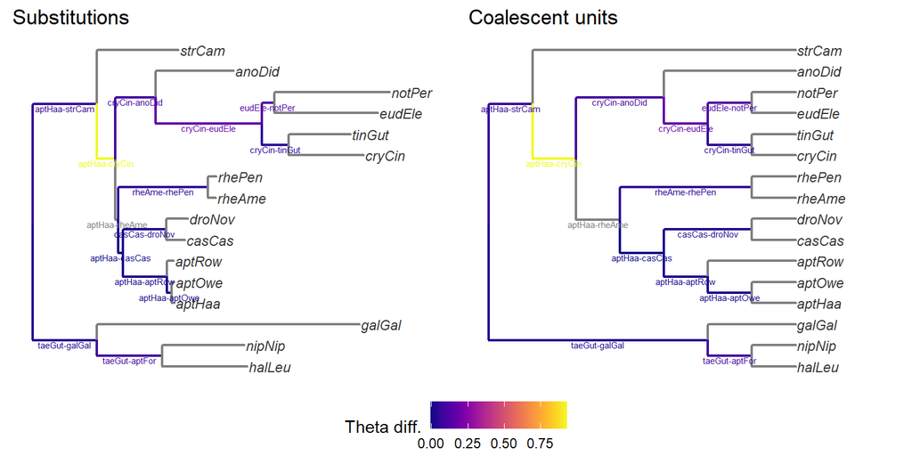

```r
sim_data_B = sim_data %>% filter(sim=="B") %>% select(-node)
# Get the data for the current case

sim_tree_info = merge(sim_tree_info_orig, sim_data_B, by="label", all.x=T)
sim_tree_info = sim_tree_info %>% arrange(node)
# Merge the current theta info with the tree info to color branches by theta.diff

sim_t = ggtree(sim_tree, size=0.8, ladderize=F, aes(color=sim_tree_info$theta.diff)) +
  scale_color_viridis(name="Theta diff.", option="C") +
  xlim(0,0.25) +
  geom_tiplab(color="#333333", fontface='italic', size=3) +
  geom_text(aes(x=branch, label=ifelse(sim_tree_info$node.type=="internal", sim_tree_info$label, "")), nudge_y=-0.2, size=2) +
  #geom_text(aes(x=branch, label=ifelse(sim_tree_info$branch.length>0, signif(sim_tree_info$branch.length, 3), "")), nudge_y=0.35, size=2) +
  ggtitle("Substitutions") +
  theme(legend.position="bottom")
#print(sim_t)
# Plot and display the tree

####################

casefile = "caseB-coalescent.tre"
coal_tree = read.tree(file=casefile)
tree_to_df_list = treeToDF(coal_tree)
coal_tree_info = tree_to_df_list[["info"]]
# Read the tree and parse the info to properly add branch labels later

coal_tree_info$label = sim_tree_info$label
# Add the labels to the coal tree info (should be ok since everything is in the same order)

coal_tree_info = merge(coal_tree_info, sim_data_B, by="label", all.x=T)
coal_tree_info = coal_tree_info %>% arrange(node)
# Merge the current theta info with the coal tree info to color branches by theta.diff

coal_t = ggtree(coal_tree, size=0.8, ladderize=F, aes(color=sim_tree_info$theta.diff)) +
  scale_color_viridis(name="Theta diff.", option="C") +
  xlim(0,9) +
  geom_tiplab(color="#333333", fontface='italic', size=3) +
  geom_text(aes(x=branch, label=ifelse(coal_tree_info$node.type=="internal", sim_tree_info$label, "")), nudge_y=-0.2, size=2) +
  #geom_text(aes(x=branch, label=ifelse(coal_tree_info$branch.length>0, signif(coal_tree_info$branch.length, 3), "")), nudge_y=0.35, size=2) +
  ggtitle("Coalescent units")
#print(coal_t)
# Plot and display the tree

leg = get_legend(sim_t)

case_B_trees_main = plot_grid(sim_t + theme(legend.position="none"),
                         coal_t + theme(legend.position="none"),
                         ncol=2)
case_B_trees = plot_grid(case_B_trees_main, leg, nrow=2, rel_heights=c(1,0.15))

print(case_B_trees)
```

```r
sim_data %>%
  filter(sim=="B") %>%
  select(label, bl.subs, bl.coal, est.theta, sim.theta, theta.diff) %>%
  rename(Branch=label, Branch.length.subs=bl.subs, Branch.length.coalescent=bl.coal, Estimated.theta=est.theta, Simulated.theta=sim.theta, Theta.diff=theta.diff) %>%
  kable() %>%
  kable_styling(bootstrap_options=c("striped", "condended", "responsive"), full_width=F)
```

| Branch | Branch.length.subs | Branch.length.coalescent | Estimated.theta | Simulated.theta | Theta.diff |
| --- | --- | --- | --- | --- | --- |
| taeGut-aptFor | 0.0415569 | 0.6405918 | 0.1297453 | 0.0457878 | 0.0839574 |
| aptHaa-aptOwe | 0.0030505 | 0.5844627 | 0.0104388 | 0.0063211 | 0.0041177 |
| cryCin-tinGut | 0.0172068 | 0.4464037 | 0.0770908 | 0.0370186 | 0.0400722 |
| eudEle-notPer | 0.0079941 | 0.0900690 | 0.1775106 | 0.0579119 | 0.1195988 |
| aptHaa-aptRow | 0.0277496 | 1.9642247 | 0.0282550 | 0.0198766 | 0.0083784 |
| casCas-droNov | 0.0273773 | 1.1909418 | 0.0459759 | 0.0296944 | 0.0162815 |
| cryCin-eudEle | 0.0672093 | 0.5243724 | 0.2563419 | 0.0955806 | 0.1607613 |
| aptHaa-casCas | 0.0028599 | 0.0713054 | 0.0802155 | 0.0864488 | -0.0062333 |
| rheAme-rhePen | 0.0566382 | 1.4279459 | 0.0793282 | 0.0278012 | 0.0515270 |
| aptHaa-rheAme | 0.0018567 | 0.0000000 | NA | 0.0587343 | NA |
| cryCin-anoDid | 0.0253604 | 0.3560659 | 0.1424478 | 0.0534954 | 0.0889523 |
| aptHaa-cryCin | 0.0118742 | 0.0238792 | 0.9945243 | 0.0649435 | 0.9295808 |
| taeGut-galGal | 0.0406841 | 1.1996290 | 0.0678278 | 0.0457878 | 0.0220400 |
| aptHaa-strCam | 0.0406969 | 1.1996290 | 0.0678491 | 0.0116277 | 0.0562215 |

# 4 Case C

For reference, here are the trees with various branch lengths

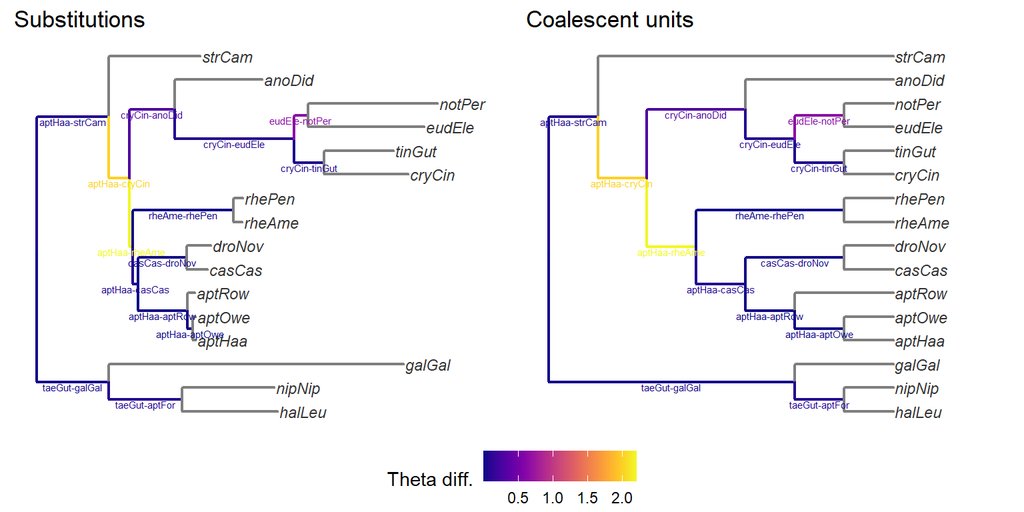

```r
sim_data_C = sim_data %>% filter(sim=="C") %>% select(-node)
# Get the data for the current case

sim_tree_info = merge(sim_tree_info_orig, sim_data_C, by="label", all.x=T)
sim_tree_info = sim_tree_info %>% arrange(node)
# Merge the current theta info with the tree info to color branches by theta.diff

sim_t = ggtree(sim_tree, size=0.8, ladderize=F, aes(color=sim_tree_info$theta.diff)) +
  scale_color_viridis(name="Theta diff.", option="C") +
  xlim(0,0.25) +
  geom_tiplab(color="#333333", fontface='italic', size=3) +
  geom_text(aes(x=branch, label=ifelse(sim_tree_info$node.type=="internal", sim_tree_info$label, "")), nudge_y=-0.2, size=2) +
  #geom_text(aes(x=branch, label=ifelse(sim_tree_info$branch.length>0, signif(sim_tree_info$branch.length, 3), "")), nudge_y=0.35, size=2) +
  ggtitle("Substitutions") +
  theme(legend.position="bottom")
#print(sim_t)
# Plot and display the tree

####################

casefile = "caseC-coalescent.tre"
coal_tree = read.tree(file=casefile)
tree_to_df_list = treeToDF(coal_tree)
coal_tree_info = tree_to_df_list[["info"]]
# Read the tree and parse the info to properly add branch labels later

coal_tree_info$label = sim_tree_info$label
# Add the labels to the coal tree info (should be ok since everything is in the same order)

coal_tree_info = merge(coal_tree_info, sim_data_C, by="label", all.x=T)
coal_tree_info = coal_tree_info %>% arrange(node)
# Merge the current theta info with the coal tree info to color branches by theta.diff

coal_t = ggtree(coal_tree, size=0.8, ladderize=F, aes(color=sim_tree_info$theta.diff)) +
  scale_color_viridis(name="Theta diff.", option="C") +
  xlim(0,9) +
  geom_tiplab(color="#333333", fontface='italic', size=3) +
  geom_text(aes(x=branch, label=ifelse(coal_tree_info$node.type=="internal", sim_tree_info$label, "")), nudge_y=-0.2, size=2) +
  #geom_text(aes(x=branch, label=ifelse(coal_tree_info$branch.length>0, signif(coal_tree_info$branch.length, 3), "")), nudge_y=0.35, size=2) +
  ggtitle("Coalescent units")
#print(coal_t)
# Plot and display the tree

leg = get_legend(sim_t)

case_C_trees_main = plot_grid(sim_t + theme(legend.position="none"),
                         coal_t + theme(legend.position="none"),
                         ncol=2)
case_C_trees = plot_grid(case_C_trees_main, leg, nrow=2, rel_heights=c(1,0.15))

print(case_C_trees)
```

```r
sim_data %>%
  filter(sim=="C") %>%
  select(label, bl.subs, bl.coal, est.theta, sim.theta, theta.diff) %>%
  rename(Branch=label, Branch.length.subs=bl.subs, Branch.length.coalescent=bl.coal, Estimated.theta=est.theta, Simulated.theta=sim.theta, Theta.diff=theta.diff) %>%
  kable() %>%
  kable_styling(bootstrap_options=c("striped", "condended", "responsive"), full_width=F)
```

| Branch | Branch.length.subs | Branch.length.coalescent | Estimated.theta | Simulated.theta | Theta.diff |
| --- | --- | --- | --- | --- | --- |
| taeGut-aptFor | 0.0415569 | 0.6738174 | 0.1233476 | 0.0457878 | 0.0775597 |
| aptHaa-aptOwe | 0.0030505 | 0.6828672 | 0.0089345 | 0.0063211 | 0.0026134 |
| cryCin-tinGut | 0.0172068 | 0.3878965 | 0.0887185 | 0.0370186 | 0.0517000 |
| eudEle-notPer | 0.0079941 | 0.0232788 | 0.6868134 | 0.0579119 | 0.6289015 |
| aptHaa-aptRow | 0.0277496 | 1.8807464 | 0.0295091 | 0.0198766 | 0.0096325 |
| casCas-droNov | 0.0273773 | 1.2943202 | 0.0423038 | 0.0296944 | 0.0126093 |
| cryCin-eudEle | 0.0672093 | 0.7572335 | 0.1775127 | 0.0955806 | 0.0819322 |
| aptHaa-casCas | 0.0028599 | 0.0365929 | 0.1563091 | 0.0864488 | 0.0698603 |
| rheAme-rhePen | 0.0566382 | 2.9268500 | 0.0387025 | 0.0278012 | 0.0109013 |
| aptHaa-rheAme | 0.0018567 | 0.0016431 | 2.2599166 | 0.0587343 | 2.2011823 |
| cryCin-anoDid | 0.0253604 | 0.1475648 | 0.3437188 | 0.0534954 | 0.2902233 |
| aptHaa-cryCin | 0.0118742 | 0.0115088 | 2.0635067 | 0.0649435 | 1.9985632 |
| taeGut-galGal | 0.0406841 | 1.1203010 | 0.0726307 | 0.0457878 | 0.0268428 |
| aptHaa-strCam | 0.0406969 | 1.1203010 | 0.0726535 | 0.0116277 | 0.0610258 |